# Data Management Final Project

By: Sierrah Mueller

This document was created as a final project for Data Management/GIS. It highlights some of the statistical analyses conducted for Chapter 2 of my thesis titled: Filling Life History Gaps in a Data-Deficient Species, redtail parrotfish, *Sparisoma chrysopterum*, in St. Thomas, US Virgin Islands. Analysis broken down by research questions:

- **Research Question 1** : Is there a difference in juvenile redtail parrotfish density between habitat types?
- **Research Question 2**: How does the percent cover of benthic substrates across all habitat types affect the density of redtail parrotfish?
- **Research Question 3**: How do complexity and depth affect the density of redtail parrotfish and vary across habitat types surveyed?

## Research Question 1

##### Is there a difference in juvenile redtail parrotfish density between habitat types?

### Data

```
## # A tibble: 6 × 13
##   MajorHabitat `0_3` `4_5` `6_10` `11_15` `16_20` `21_30` `31_40` `41_50`
##   <chr>        <dbl> <dbl>  <dbl>   <dbl>   <dbl>   <dbl>   <dbl>   <dbl>
## 1 Rocky Reef       0     1      3       2       0       0       0       0
## 2 Rocky Reef       0     0      4       4       2       0       0       0
## 3 Rocky Reef       0     0      4       3       1       0       0       0
## 4 Rocky Reef       0     1      3       1       2       0       0       0
## 5 Rocky Reef       0     0      1       1       0       0       0       0
## 6 Rocky Reef       0     2      0       0       0       0       0       0
## # ℹ 4 more variables: `51_60` <dbl>, `61_70` <dbl>, totalabun <dbl>,
## #   density <dbl>
```

### Results

#### **Kruskal Wallis Test**

Kruskal Wallis test conducted to examine relationship between redtail parrotfish density by habitat type surveyed: hardbottom, rocky reef, and seagrass fringe. Kruskal Wallis test followed by a pairwise wilcox test for post-hoc analysis.

```r
kruskal.test(density ~ MajorHabitat, data = density_df)
```

```
##
##  Kruskal-Wallis rank sum test
##
## data:  density by MajorHabitat
## Kruskal-Wallis chi-squared = 62.629, df = 2, p-value = 2.514e-14
```

```r
pairwise.wilcox.test(density_df$density, density_df$MajorHabitat,
                     p.adjust.method = "BH")
```

```
##
##  Pairwise comparisons using Wilcoxon rank sum test with continuity correction
##
## data:  density_df$density and density_df$MajorHabitat
##
##                 Hardbottom Rocky Reef
## Rocky Reef      0.037      -
## Seagrass Fringe 2.4e-13    8.8e-09
##
## P value adjustment method: BH
```

### Plot

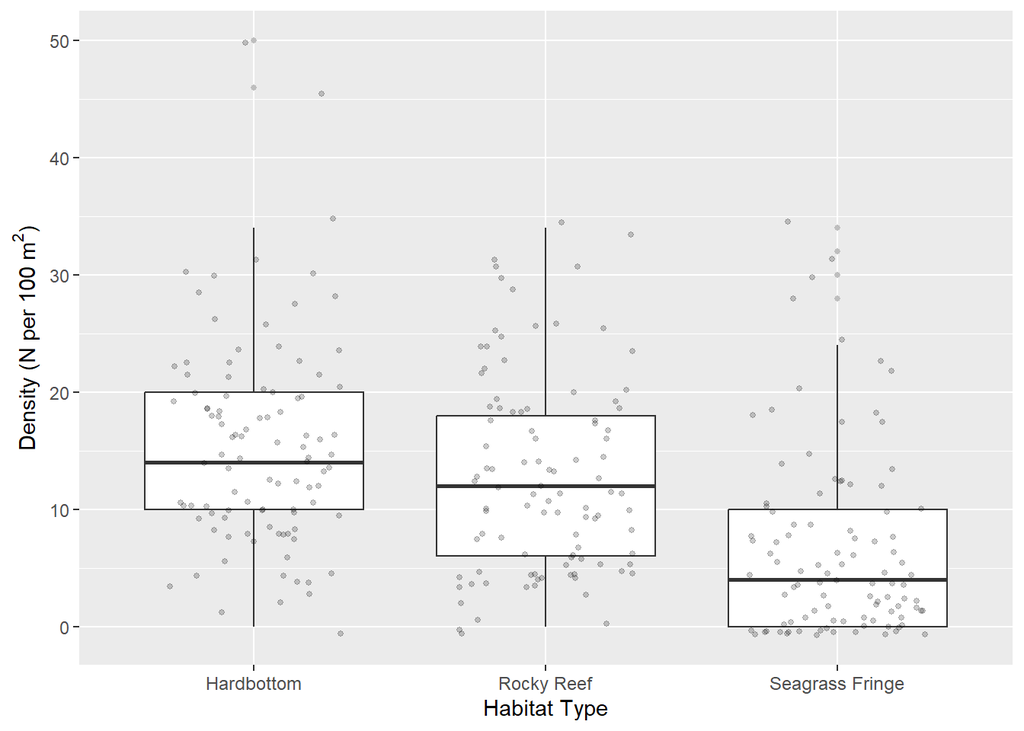

Figure: Redtail parrotfish density (N per 100 m2) across hardbottom, rocky reef, and seagrass fringe habitats.

## Research Question 2

##### How does the percent cover of benthic substrates across all habitat types affect the density of redtail parrotfish?

### Data

```
## # A tibble: 6 × 32
##   SiteCode Site     Habitat Abundance AvgDepth Complexity CORAL GORGONIAN SPONGE
##      <dbl> <chr>    <chr>       <dbl>    <dbl>      <dbl> <dbl>     <dbl>  <dbl>
## 1        1 Bolongo… Hardbo…         1      6.5       24.5 0         0      0
## 2        1 Bolongo… Hardbo…         5     10         23.9 0.271     0      4.07
## 3        1 Bolongo… Hardbo…         5      9         19.3 0.519     0.260  0.260
## 4        1 Bolongo… Hardbo…         7      9         31.7 0         0      0
## 5        1 Bolongo… Hardbo…         2      9         19.4 0         0.258  0
## 6        1 Bolongo… Hardbo…         4      7.5       26.1 0         0      0.259
## # ℹ 23 more variables: ZOANTHID <dbl>, MACROALGAE <dbl>, CCA <dbl>,
## #   CYANOBACTERIA <dbl>, TURF <dbl>, Nonliving <dbl>, SEAGRASS <dbl>,
## #   THALASSIA <dbl>, SYRINGODIUM <dbl>, HALOPHILA <dbl>, OTHER <dbl>,
## #   AMPH <dbl>, CLAD <dbl>, Dictyota <dbl>, HALI <dbl>, LIAG <dbl>, LOBO <dbl>,
## #   MACA <dbl>, MICRO <dbl>, PEY <dbl>, RAMI <dbl>, SARG <dbl>, MacaUNSP <dbl>
```

### Results

#### **Negative Binomial Regression (NBR)**

NBR to examine the relationship between the benthic substrate variables: Macroalgae unspecified, Dictyota, Turf, Coral, Seagrass, and Sponge on the juvenile redtail parrotfish density. NBR followed by a goodness of fit test to ensure NBR regression model fitted better than Poisson model.

```r
m_benthic <- glm.nb(Abundance ~ MacaUNSP + Dictyota + TURF + SEAGRASS + CORAL + SPONGE , data = glm_df)
summary(m_benthic)
```

```
##
## Call:
## glm.nb(formula = Abundance ~ MacaUNSP + Dictyota + TURF + SEAGRASS +
##     CORAL + SPONGE, data = glm_df, init.theta = 2.115124016,
##     link = log)
##
## Coefficients:
##              Estimate Std. Error z value Pr(>|z|)
## (Intercept) 1.309e+00  2.554e-01   5.123 3.01e-07 ***
## MacaUNSP    1.143e-02  7.689e-03   1.487  0.13703
## Dictyota    1.579e-02  5.107e-03   3.091  0.00199 **
## TURF        8.963e-05  3.841e-03   0.023  0.98138
## SEAGRASS    4.993e-04  3.436e-03   0.145  0.88448
## CORAL       1.156e-02  2.160e-02   0.535  0.59254
## SPONGE      3.727e-02  2.144e-02   1.739  0.08212 .
## ---
## Signif. codes:  0 '***' 0.001 '**' 0.01 '*' 0.05 '.' 0.1 ' ' 1
##
## (Dispersion parameter for Negative Binomial(2.1151) family taken to be 1)
##
##     Null deviance: 381.89  on 296  degrees of freedom
## Residual deviance: 351.36  on 290  degrees of freedom
##   (3 observations deleted due to missingness)
## AIC: 1649.6
##
## Number of Fisher Scoring iterations: 1
##
##
##               Theta:  2.115
##           Std. Err.:  0.264
##
##  2 x log-likelihood:  -1633.634
```

```r
odTest(m_benthic)
```

```
## Likelihood ratio test of H0: Poisson, as restricted NB model:
## n.b., the distribution of the test-statistic under H0 is non-standard
## e.g., see help(odTest) for details/references
##
## Critical value of test statistic at the alpha= 0.05 level: 2.7055
## Chi-Square Test Statistic =  308.0922 p-value = < 2.2e-16
```

### Plot

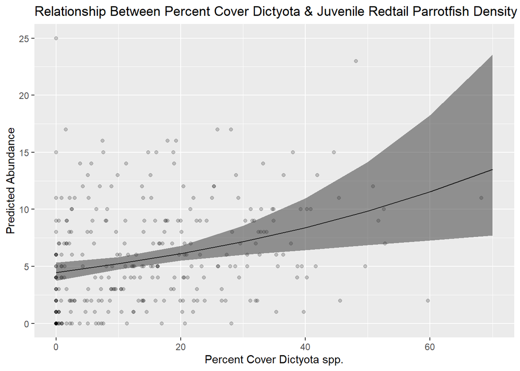

Figure: Negative Binomial regression of the predicted density of redtail parrotfish in the presence of biological substrate Dictyota spp across all habitat types.

## Research Question 3

##### How do complexity and depth affect the density of redtail parrotfish and vary across habitat types surveyed?

### Data

```
## # A tibble: 6 × 14
##   SiteCode Site   MajorHabitat size1 size2 size3 size4 size5 size6 size7 Density
##      <dbl> <chr>  <chr>        <dbl> <dbl> <dbl> <dbl> <dbl> <dbl> <dbl>   <dbl>
## 1        1 Bolon… Rocky Reef       0     1     3     2     0     0     0       6
## 2        1 Bolon… Rocky Reef       0     0     4     4     2     0     0      10
## 3        1 Bolon… Rocky Reef       0     0     4     3     1     0     0       8
## 4        1 Bolon… Rocky Reef       0     1     3     1     2     0     0       7
## 5        1 Bolon… Rocky Reef       0     0     1     1     0     0     0       2
## 6        1 Bolon… Rocky Reef       0     2     0     0     0     0     0       2
## # ℹ 3 more variables: Complexity <dbl>, AvgDepth <dbl>, DepthMeters <dbl>
```

### Results

#### **Part 1: Negative Binomial Regression (NBR)**

Examine the relationship between habitat characteristics complexity and depth on juvenile redtail parrotfish density

```r
m_depthcomplex <- glm.nb(Density ~ Complexity + AvgDepth, data = noout)
summary(m_depthcomplex)
```

```
##
## Call:
## glm.nb(formula = Density ~ Complexity + AvgDepth, data = noout,
##     init.theta = 1.898846626, link = log)
##
## Coefficients:
##             Estimate Std. Error z value Pr(>|z|)
## (Intercept) 1.321082   0.131082  10.078  < 2e-16 ***
## Complexity  0.013927   0.003657   3.808  0.00014 ***
## AvgDepth    0.018409   0.012100   1.521  0.12814
## ---
## Signif. codes:  0 '***' 0.001 '**' 0.01 '*' 0.05 '.' 0.1 ' ' 1
##
## (Dispersion parameter for Negative Binomial(1.8988) family taken to be 1)
##
##     Null deviance: 360.16  on 296  degrees of freedom
## Residual deviance: 347.87  on 294  degrees of freedom
## AIC: 1662.4
##
## Number of Fisher Scoring iterations: 1
##
##
##               Theta:  1.899
##           Std. Err.:  0.225
##
##  2 x log-likelihood:  -1654.413
```

```r
odTest(m_depthcomplex)
```

```
## Likelihood ratio test of H0: Poisson, as restricted NB model:
## n.b., the distribution of the test-statistic under H0 is non-standard
## e.g., see help(odTest) for details/references
##
## Critical value of test statistic at the alpha= 0.05 level: 2.7055
## Chi-Square Test Statistic =  377.1627 p-value = < 2.2e-16
```

#### **Part 2: Kruskal Wallis Test**

Examine differences in topographic complexity between habitat types followed by post hoc analysis using pairwise wilcox test

```r
kruskal.test(Complexity ~ MajorHabitat, data = nbr_complexdepth)
```

```
##
##  Kruskal-Wallis rank sum test
##
## data:  Complexity by MajorHabitat
## Kruskal-Wallis chi-squared = 129.35, df = 2, p-value < 2.2e-16
```

```r
pairwise.wilcox.test(nbr_complexdepth$Complexity, nbr_complexdepth$MajorHabitat,
                     p.adjust.method = "BH")
```

```
##
##  Pairwise comparisons using Wilcoxon rank sum test with continuity correction
##
## data:  nbr_complexdepth$Complexity and nbr_complexdepth$MajorHabitat
##
##            Hardbottom Rocky Reef
## Rocky Reef 4.1e-11    -
## Seagrass   1.5e-12    < 2e-16
##
## P value adjustment method: BH
```

### Plots

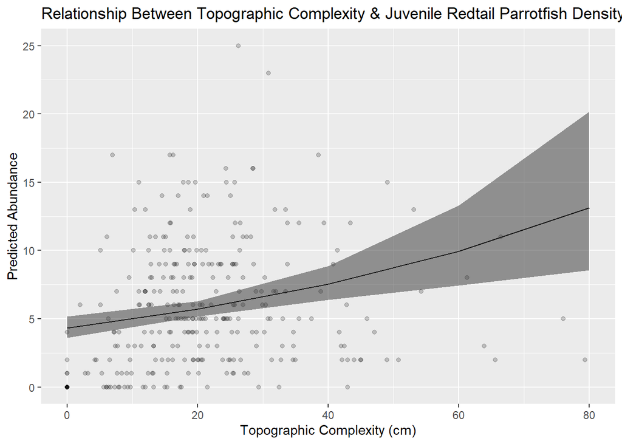

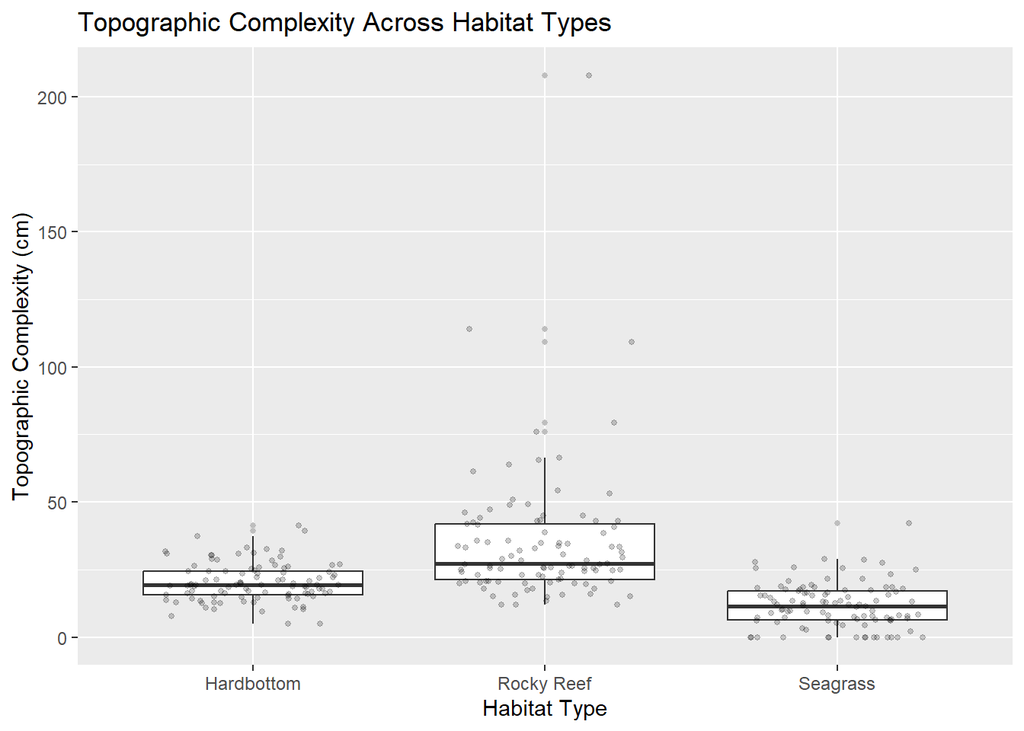